# myspotify

The goal of `myspotify` is to to read personal Spotify data and complete a series of analyses. Spotify is a popular music and podcast streaming app globally.

## What’s this package for?

Spotify, a popular music streaming platform, offers users the option to download their personal usage history data. `myspotify` seeks to provide tools to allow users to read and visualize their data to learn more about their listening habits. The idea is somewhat similar to “Spotify Wrapped,” a personalized summary that Spotify releases annually, but this can assess history beyond just a year and allows the user to delve into the patterns of the songs they listen to on Spotify.

## Who should use this package?

Anyone who uses Spotify, wants to learn more about their listening habits, and has a basic background in (or is willing to learn!) R.

“Basic background” might include understanding variable assignment (`<-`) and various Tidyverse packages like dplyr and ggplot2. Tidyverse familiarity is not necessary but would allow for more data exploration opportunities.

## What datasets are there?

- `extended_example`: example dataset of Spotify listening history from one of the authors
- **Load your own!**

To download and load your personal data:

- Go to the [Spotify website](http://spotify.com) and login.
- Once logged in, access your account by clicking on your profile picture and name in the upper right hand corner, and selecting Account from the dropdown menu. In the menu on the left hand side of the Account Overview page, select Privacy Settings.
- At the bottom of this page, under “Download your data,” check the box under “Extended streaming history” and UNcheck the box under “Account data.”
  - This package doesn’t support analysis of data requested by “Account data.” But feel free to download it if you’d like to do independent exploration!
- Click the button at the bottom of the page that says “Request data,” and follow the instructions on the page from there (email confirmation).
- The data will take up to 30 days to arrive. You’ll receive an email that will lead you to download a .Zip file. Unzip/extract the contents. Inside the folder “my_spotify_data,” you’ll find another folder called “MyData.” Inside this folder will be a single file called endsong.json or multiple files named endsong_X.json, where X is a number.
- Use the file paths to these files with `myspotify::read_file()` to read the data into R. (See below for further instructions.)

## What does the data look like?

Here’re the first 5 rows of the `extended_example` dataset:

```r
head(extended_example, 5)
```

```
#>         date                time ms_played                song
#> 1 2022-03-30 2022-11-17 00:44:38      1965              Sue Me
#> 2 2019-11-22 2022-11-17 02:14:01    222951 Cat's in the Cradle
#> 3 2021-11-02 2022-11-17 15:55:07    203444          Homecoming
#> 4 2022-07-30 2022-11-17 12:44:44    123949       don't miss me
#> 5 2022-07-17 2022-11-17 14:43:40    159836   abcdefu (angrier)
#>              artist                 album reason_start reason_end year
#> 1 Sabrina Carpenter        Singular Act I       remote    endplay 2022
#> 2      Harry Chapin Verities & Balderdash    trackdone  trackdone 2019
#> 3        Kanye West            Graduation    trackdone  trackdone 2021
#> 4 Claire Rosinkranz         don’t miss me    trackdone  trackdone 2022
#> 5             GAYLE     abcdefu (angrier)    trackdone  trackdone 2022
```

In this dataset, each row or “case” is one *instance* of a song having been listened to. Each case includes information about this session: what song was played and who it was by, what album the song is in, what time the song was played (determined by when it stopped playing), and more.

## What can we do with this package?

We can answer questions like: - What music do I listen to? - By artist, by song, by words in the title of the song. - How do I listen to music? - By time of day, by frequency over the years, by skipping frequency, by which songs were skipped before they were played for at least a minute, two minutes…

This package contains a variety of functions made to analyze a user’s extended streaming history by providing descriptive statistics in the forms of tables and plots. A user can use these functions for more in-depth analysis on their own.

There are functions to look at metadata of how the user interacts with the music, such as which songs the time of day (`plot_times()`), or how the user’s listening frequency changes over time (`timeseries()`).

# Function walk-throughs

## Data wrangling functions

### Function: `read_file()`

`read_file()` takes links or filepaths to JSON files and reads them into a dataframe object in R. It can take one or multiple files at a time: note that you can read all of your files at once, with the file paths in quotes, separated by commas. This function is required for using any of the other functions in this package.

Also good to note is the variable assignment at the beginning of the example below (`my_data <-`). The variable (`my_data`) will then be the dataframe that you can feed into the other functions in this package.

```r
# example:
# my_data <- read_file("workspace/my_spotify_data/myData/endsong_0.json",
#                      "workspace/my_spotify_data/myData/endsong_1.json",
#                      "workspace/my_spotify_data/myData/endsong_2.json")
```

### Function: `filter_playtime()`

Spotify data by default includes all songs that started playing, including songs that, for instance, only played for three seconds before getting skipped. `filter_playtime()` allows you to ignore the instances in which a song’s playing time hasn’t met a threshold that you’ve decided (given to parameter `length` in minutes).

The dataframe produced from this function is compatible with other functions in this package, including the plotting functions. See an example in the `artist_trends()` function description.

```r
# Selects songs that have played for one OR MORE minutes
one_min <- filter_playtime(extended_example, length = 1)

# Selects songs that have played for 2.5 OR MORE minutes
# Can use with dplyr's pipe ( %>% ) function!
twoandhalf <- extended_example %>%
  filter_playtime(length = 2.5)
```

### Function: `most_skipped()`

`most_skipped()` returns a dataframe with columns `song` and `skips`, where skips counts the number of listening instances that were ended because the user hit the “forward button” while listening, i.e., the user skipped the song.

You can change what the skips are organized by with the parameter `by`, which can take any of the column names. For instance, `by = "artist"` would return a dataframe with the number of times the user has skipped any song by each artist. And `by = "song"` counts the number of skips per song (this is the default).

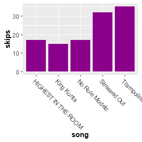

```r
# Plot the top 5 most skipped songs
skipped_songs <- extended_example %>%
  most_skipped() %>%
  arrange(desc(skips)) %>% # order rows by number of skips, most to least
  head(5) # select only the top 5 rows

# plotting the dataframe of 5 songs from above
ggplot(skipped_songs, aes(x = song, y = skips)) +
  geom_col(fill= "darkmagenta") +
  theme(axis.text.x = element_text(angle = -45, hjust = 0)) +
  theme(axis.title = element_text(face="bold"))
```

### Function: `play_btn()`

`play_btn()` returns a dataframe with columns `song`, `artist`, and `n`, where `n` is the number of instances where the user manually the “play button” to start the song the most. (This likely means that it was the first song played.) Just enter your dataframe!

```r
play_btn(extended_example)
```

```
#> # A tibble: 306 × 3
#> # Groups:   song, artist [306]
#>    song                            artist                 n
#>    <chr>                           <chr>              <int>
#>  1 King Kunta                      Kendrick Lamar        10
#>  2 Killing Me Softly With His Song Fugees                 9
#>  3 Alone Again (Naturally)         Gilbert O'Sullivan     8
#>  4 Love Story (Taylor’s Version)   Taylor Swift           8
#>  5 You Don't Own Me                Lesley Gore            8
#>  6 How Deep Is Your Love           Bee Gees               7
#>  7 Wild Mountain Thyme             Celtic Woman           7
#>  8 29                              Demi Lovato            6
#>  9 9 to 5                          Dolly Parton           6
#> 10 Cat's in the Cradle             Harry Chapin           6
#> # … with 296 more rows
```

### Function: `search_word()`

`search_word()` returns a dataframe with columns `song`, `artist` and `album`, whose song names contain a word or phrase of your choice. It takes the dataframe name followed by the word or phrase of your choice (in quotation marks). Capitalization of the word or phrase of your choice does not matter.

```r
#Example word: "You"
search_word(extended_example, "you")
```

```
#>                                                                                                           song
#> 1                                                                                        Every Breath You Take
#> 2                                                                                      I'd Love You to Want Me
#> 3                                                                                          If You Leave Me Now
#> 4                                                                                              Burnin' for You
#> 5                                                                                 you should see me in a crown
#> 6                                                                                             till you hate me
#> 7                                                                       You're the Inspiration - 2006 Remaster
#> 8                                                                                  Have You Ever Seen The Rain
#> 9                                                                                          Put Your Records On
#> 10                                                                                             Open Your Heart
#> 11                                                                       Arthur's Theme (Best That You Can Do)
#> 12                                                                                       How Deep Is Your Love
#> 13                                                                                                  Youngblood
#> 14                                                                             I Just Called To Say I Love You
```

[output cut: 684 more lines]

```r
# Returns all songs streamed with "you" in the title
```

## Plotting functions

**Note** : all plots produced by functions in this package are ggplot2 objects. Feel free to experiment with adding other ggplot2 elements, such as labels, formatting, etc.!

### Function: `most_played_artists()`

`most_played_artists()` makes a plot of the top ten artists/bands streamed of all time (cumulatively over the years). Just enter a dataframe!

```r
most_played_artists(extended_example)
```

```
#> [1] "Your most played artist of all time is Taylor Swift! Followed by (the)Bee Gees and Olivia Rodrigo"
```

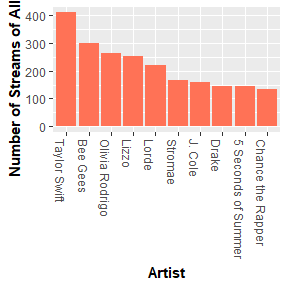

### Function: `artist_trends()`

`artist_trends()` is similar to `most_played_artists()`, but breaks up the data by year. This function plots only three artists per year by default, and you can can change how many artists are displayed with `num`.

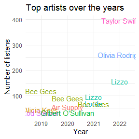

```r
# Top three artists for all songs that were played
artist_trends(extended_example, )
```

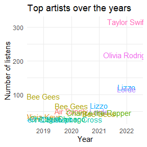

```r
# Say we only want to see artists whose songs we played for at least 2 minutes...
# But we want to see four artists per year
extended_example %>%
  filter_playtime(length = 2) %>%
  artist_trends(num = 4)
```

### Function: `plot_times()`

`plot_times()` plots the time of day that the user played the song. Aside from the dataframe, there are two optional parameters: `targetTZ` and `years`. `targetTZ` is the timezone in which you would like to plot the times of day, where the default is Coordinated Universal Time. See ideas for inputs [here](https://stat.ethz.ch/R-manual/R-devel/library/base/html/timezones.html). In `years`, you can select specific years to plot for.

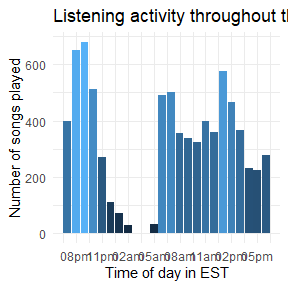

```r
plot_times(extended_example, targetTZ = "EST", years = c(2019, 2022))
```

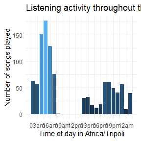

```r
plot_times(extended_example, targetTZ = "Africa/Tripoli", years = 2020)
```

### Function: `timeseries()`

`timeseries()` plots a timeseries of the number of songs that the user played over time. It takes the dataframe a number of optional parameters: `interval`, which is the time interval to group listens by, e.g., by week, month, year. `limits`, `breaks`, and `geom` are similar to the terms used in ggplot2.

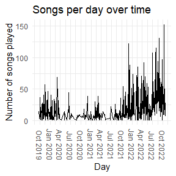

```r
t <- c("2021-01-01 00:00:00", "2022-01-01 00:00:00")
timeseries(extended_example, interval = "month", limits = t, breaks = "3 months")

timeseries(extended_example, interval = "day", breaks = "3 months", geom = "line") +
  theme(axis.text.x = ggplot2::element_text(angle = 270, vjust = 0.5, hjust=1))
```

[output not shown]